# Clean & dirty energy: complements or substitutes? Selling solar to small shops in Lagos

Emilia Tjernström

with: Lori Beaman Joshua Deutschmann Lauriane Yehouenou

Transforming Energy Markets Seminar Series

2 November 2026

# Motivation

## Motivation: three guesses

1. Lagos shops on the grid: how many days a week with power all day?

   0.4 days a week
2. What share would pay the retail price for a small solar kit?

   Almost none
3. Cheaper solar: more or less generator use?

   More generator use

## Context: on the grid, rarely powered

- 91% of shops were on the grid
- 90% of them lacked a full day of power
- 25% also used a generator
- Generator users spent 6× as much on energy
- Only 4% already owned solar

[figure not shown]

## Context: Nigeria runs on small generators

- An estimated 22 million small petrol generators in use

  (Access to Energy Institute and Dalberg, 2019)
- About USD 12 billion a year to buy & run them
- Firms: electricity a top obstacle; 33 outages a month

  (World Bank, 2014)
- Petrol price: NGN 238 $\rightarrow$ 546 a liter in one month (2023)

  (National Bureau of Statistics, 2023)

## Question: does cheaper solar replace generators?

- Small solar: quiet, clean, no fuel to buy
- If solar substitutes $\rightarrow$ $\downarrow$ generator use & fuel
- If solar complements $\rightarrow$ generator use could $\uparrow$
- The answer matters for subsidies & for emissions

[figure not shown]

## What we do & preview of results

# Design

## Context: the shops & the kit

- 401 shops in four Lagos markets
- Kit: 4 lamps, 15 W panel, 40 Wh battery
- Retail: NGN 140,000 ($\approx$ AUD 150)
- Arms: Control, Information, Free trial

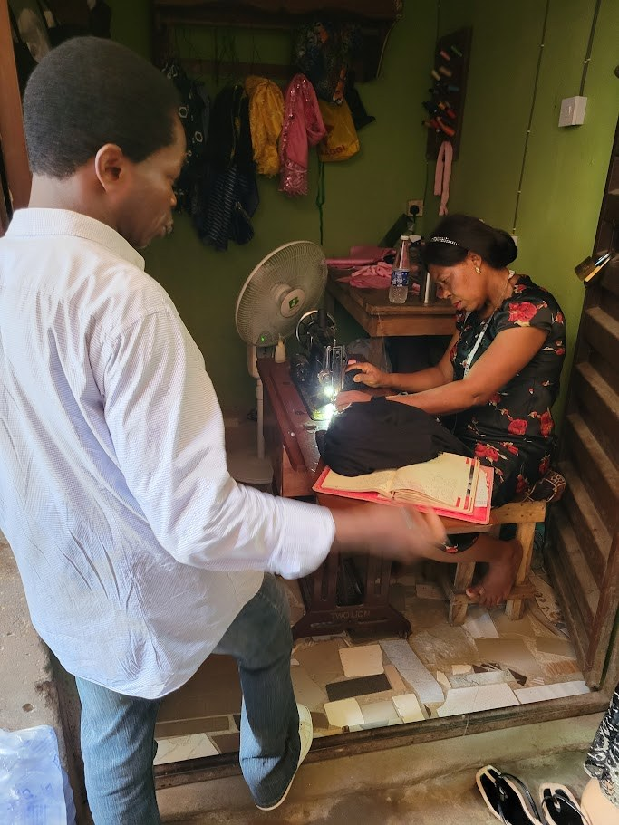

Information treatment

## Design: a lottery that reveals what shops would pay

1. Shop names the most it would pay
2. Shop draws a sealed envelope with a random price
3. Price $\leq$ bid $\rightarrow$ shop buys at the drawn price
4. Price $>$ bid $\rightarrow$ no sale

$\rightarrow$ naming your true value is the best strategy

## Design: neighbors drew similar prices

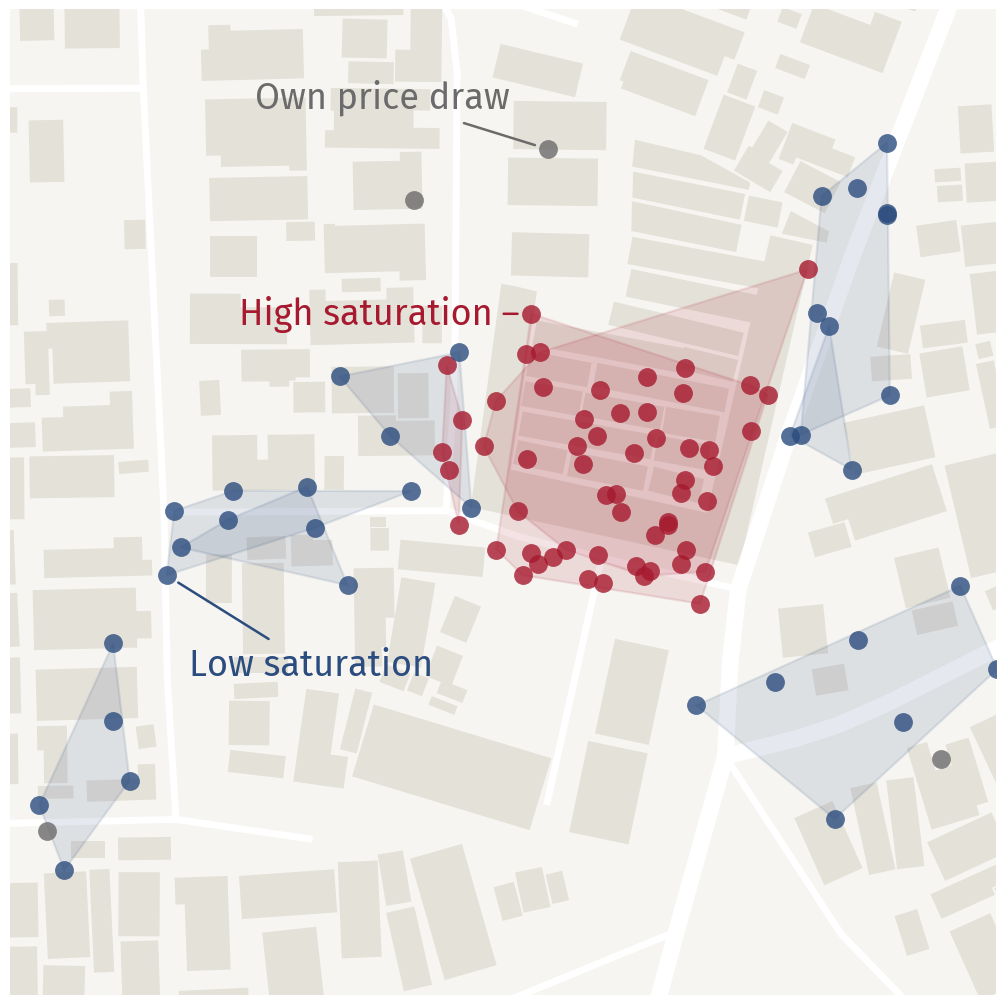

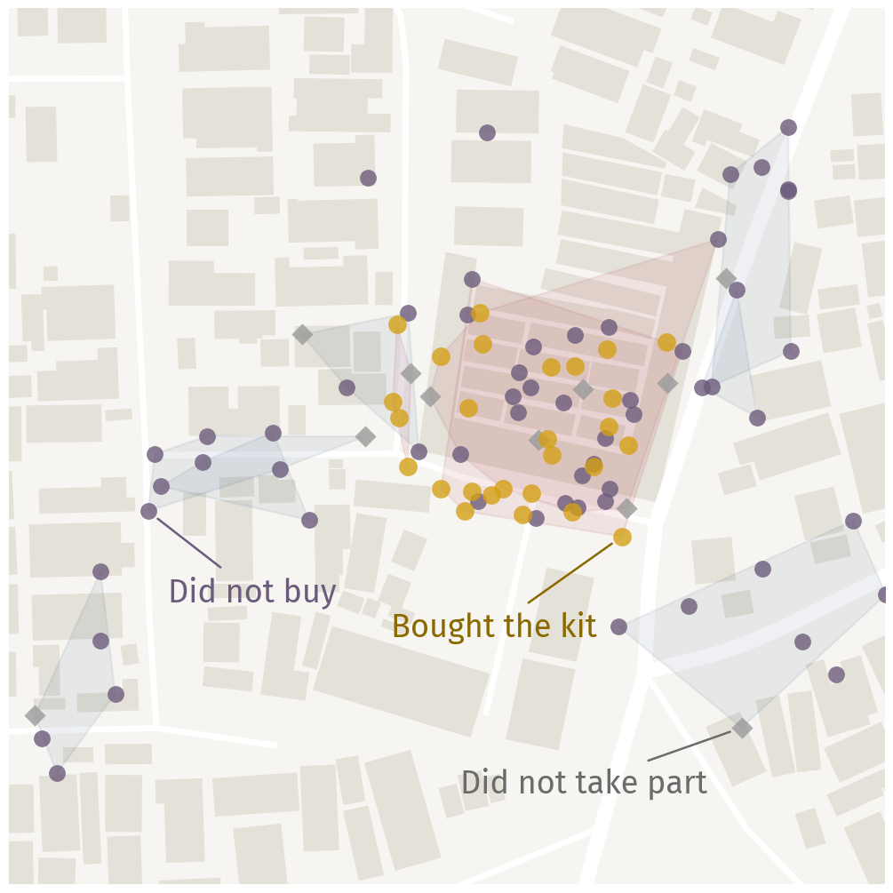

Prices by arm All four markets

## Take-up: price drives purchases

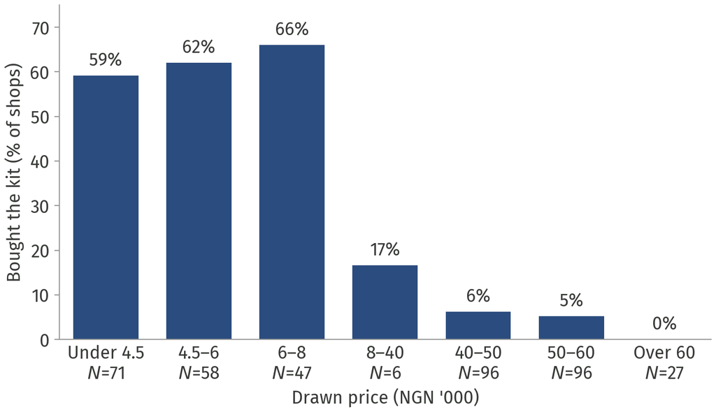

Take-up maps

# Results

## Demand: almost no shop would pay the retail price

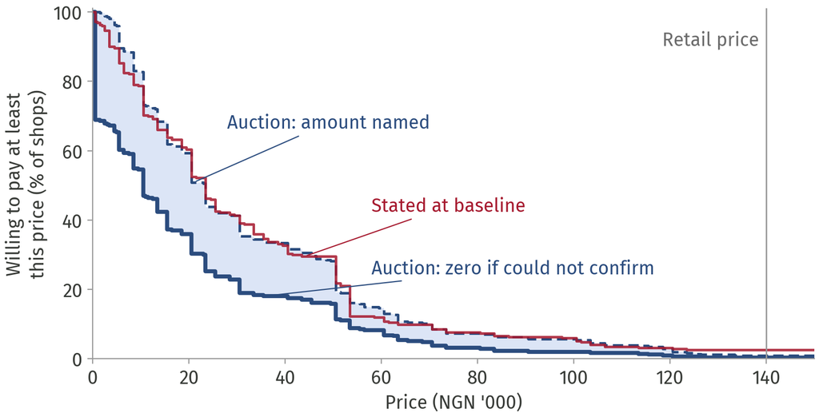

Stated vs auction

## Generators: cheaper solar, more generator use

|  | Phone surveys Ran a generator | Phone surveys Generator days | Phone surveys Fuel spending | Endline Has a generator | Endline Energy spending |
| --- | --- | --- | --- | --- | --- |
| Drawn price (NGN 10,000) | −0.015 | −0.076** | −0.135 | −0.009 | −0.003 |
|  | (0.009) | (0.033) | (0.114) | (0.008) | (0.056) |
| Bought the kit (2SLS) | 0.239 | 1.260** | 2.209 | 0.158 | 0.046 |
|  | (0.152) | (0.537) | (1.804) | (0.139) | (0.957) |
| Control mean | 0.144 | 0.593 | 1.413 | 0.136 | 1.765 |
| Observations | 648 | 648 | 643 | 348 | 321 |
| Firms | 371 | 371 | 370 | 348 | 321 |

Fuel and energy spending in NGN ’000 a week; standard errors clustered by price cluster  
Stars from randomization inference: * 10%, ** 5%, *** 1%

Equations Permutation test Leave one out Specifications

## Generators: the pattern shows up across energy measures

|  | Drawn price (NGN 10,000) Spending | Drawn price (NGN 10,000) Generator use | Drawn price (NGN 10,000) All five | Bought the kit (2SLS) Spending | Bought the kit (2SLS) Generator use | Bought the kit (2SLS) All five |
| --- | --- | --- | --- | --- | --- | --- |
| All shops | −0.020 | −0.046** | −0.043** | 0.363 | 0.836** | 0.791** |
|  | (0.016) | (0.022) | (0.020) | (0.278) | (0.383) | (0.357) |
| *N* | 391 | 393 | 393 | 391 | 393 | 393 |
| Confirmed payment | −0.048*** | −0.083*** | −0.074*** | 0.481*** | 0.841*** | 0.746*** |
|  | (0.014) | (0.022) | (0.020) | (0.157) | (0.251) | (0.224) |
| *N* | 238 | 239 | 239 | 238 | 239 | 239 |

Indices in SD units; standard errors clustered by price cluster  
Stars from randomization inference: * 10%, ** 5%, *** 1%

## Mechanism: the kit powered lights; generators powered fans

- 77% of shops powered a fan
- 93% of generator users ran a fan on it
- Buyers used the kit for lights (100%), rarely a fan (7%)
- 83% would run a fan or AC on a bigger system

## Takeaways for energy markets

- Shops valued small solar far below its retail price
- Subsidies raised take-up a lot
- …but cheaper solar didn’t displace the generator
- Generators powered fans; the kit powered lights

# Appendix

## Estimating equations

$$\text{Bought}_i = \pi \, \text{Price}_i + \gamma \, Y_{i0} + \delta_{m(i)} + \lambda_{s(i)} + u_i$$

$$Y_i = \beta \, \text{Price}_i + \gamma \, Y_{i0} + \delta_{m(i)} + \lambda_{s(i)} + \varepsilon_i$$

$$Y_i = \theta \, \widehat{\text{Bought}}_i + \gamma \, Y_{i0} + \delta_{m(i)} + \lambda_{s(i)} + e_i$$

- $\text{Price}_i$: shop’s drawn price; $Y_{i0}$: baseline outcome
- $\delta_{m}$: market; $\lambda_{s}$: saturation arm
- Standard errors clustered by price cluster

Back

## Inference: permutation test for generator days

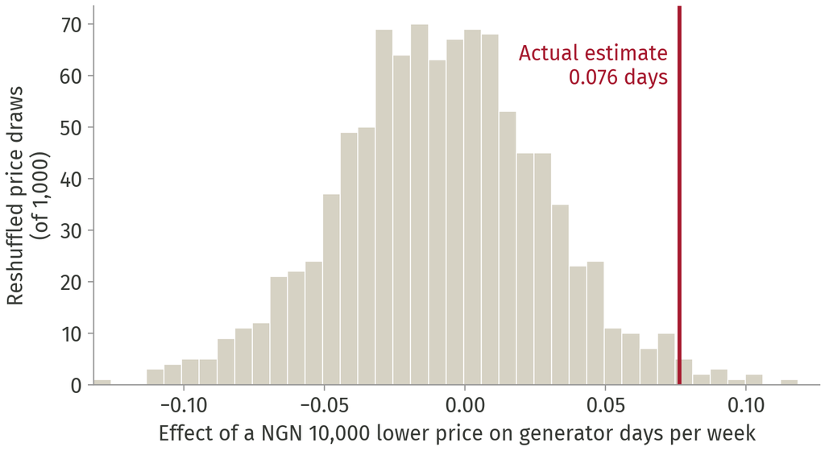

Back

## Robustness: dropping one cluster at a time

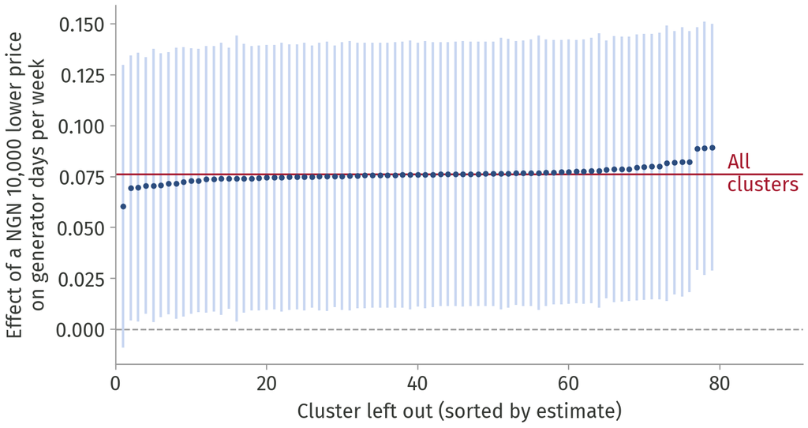

Back

## Robustness: alternative specifications

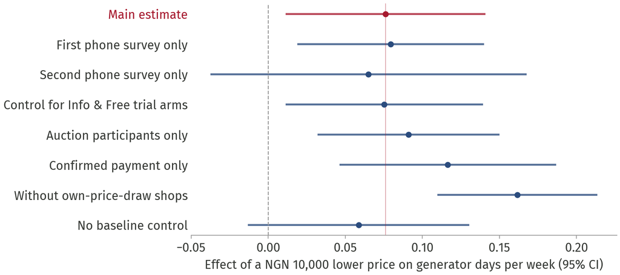

Back

## Demand: stated vs auction willingness to pay

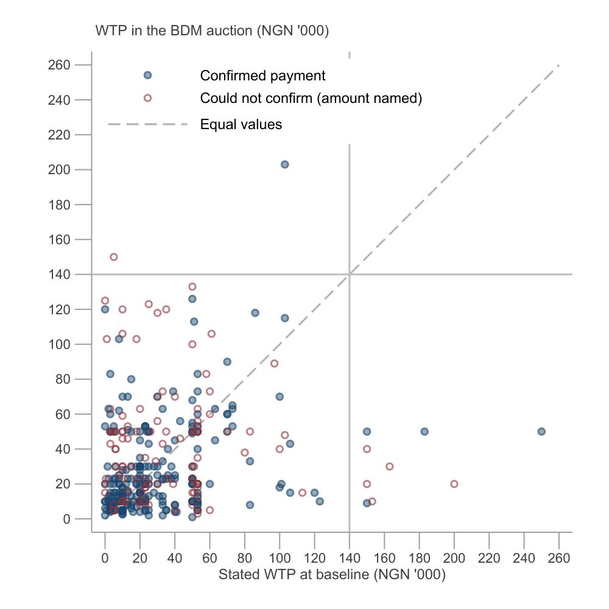

Back

## Design: drawn prices by saturation arm

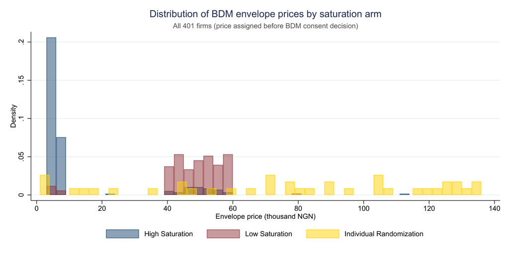

Back

## Design: the information treatment

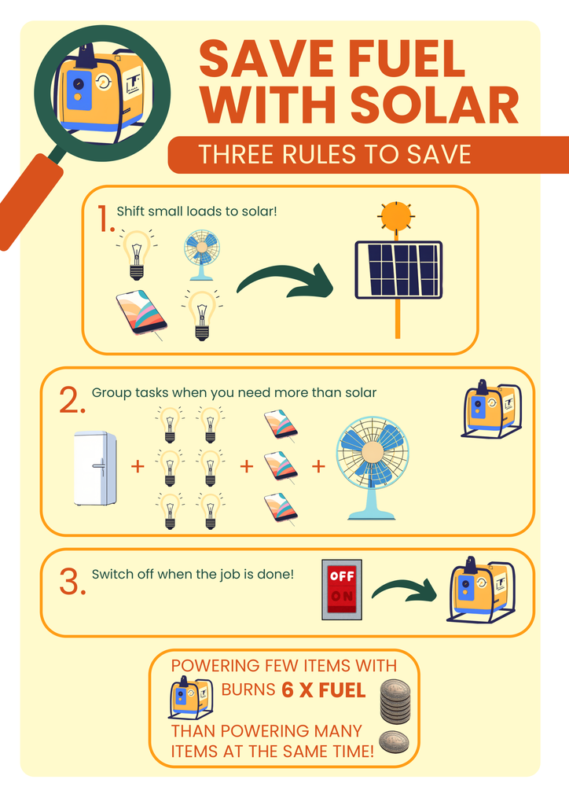

Back

## Design: saturation arms in all four markets

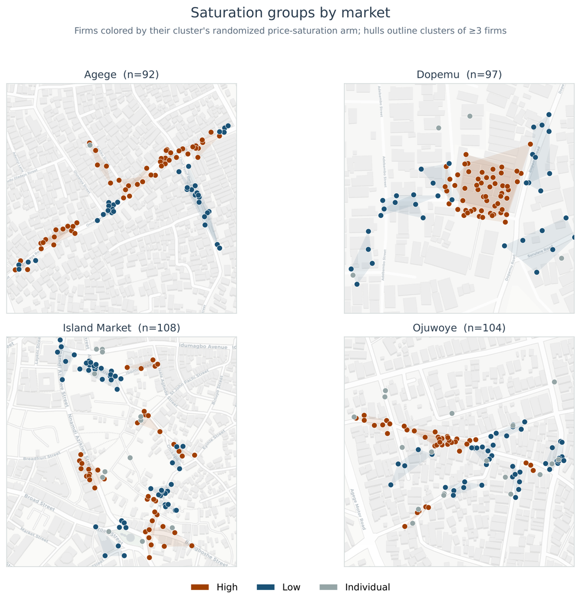

Back

## Take-up in all four markets

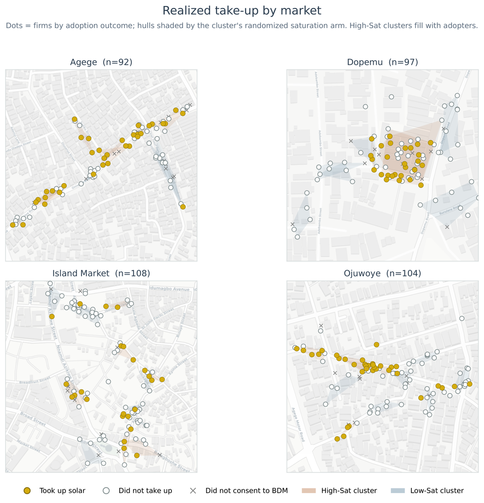

Back